# Bayesian Linear Regression

# Model Comparison: LOO

- One way to compare two models fit on the same data after adding a parameter is by using an approximation to leave-one-out cross-validation. There is a `loo` function available to accomplish this. This is the currently recommended method in rstanarm for model comparisons. It can be time and resource intensive for larger models, so use the `cores=` argument if you have multicore available.
- loo stands for leave one out - ‘Pareto smoothed importance-sampling leave-one-out cross-validation (PSIS-LOO)’. This is fairly complex - check this link for more info: https://mc-stan.org/loo/articles/loo2-example.html

And check these papers:

- Vehtari, A., Gelman, A., and Gabry, J. (2017). Practical Bayesian model evaluation using leave-one-out cross-validation and WAIC. Statistics and Computing. 27(5), 1413–1432. :10.1007/s11222-016-9696-4. Links: published | arXiv preprint.
- Vehtari, A., Simpson, D., Gelman, A., Yao, Y., and Gabry, J. (2019). Pareto smoothed importance sampling. arXiv preprint arXiv:1507.04544.

```r
library(loo)
# calculate loo and compare
loo0 <- loo(fit0,
            cores=1) # increase cores argument if you can
loo1 <- loo(fit1)
loo2 <- loo(fit2)
loo_compare(loo0,loo1)
```

```
##      elpd_diff se_diff
## fit1   0.0       0.0
## fit0 -10.1       4.8
```

```r
loo_compare(loo1,loo2)
```

```
##      elpd_diff se_diff
## fit2  0.0       0.0
## fit1 -5.4       3.5
```

```r
# compare all
loo_compare(loo0,loo1,loo2)
```

```
##      elpd_diff se_diff
## fit2   0.0       0.0
## fit1  -5.4       3.5
## fit0 -15.5       5.6
```

The model with the lowest LOO information criterion is the ‘best fit’ to the data. The standard error of the difference gives us an idea of if that difference is substantial. Fit2 is the best, though the difference between fit1 and fit2 is only ~1.5 standard deviations (5.5/3.5).

# Other functions

- That polynomial is an apparent improvement, but still not exactly the shape we want!
- What type of function will give me the shape I want?
- conc to the power of something less than one I think.

```r
# Fit model with concentration, specifying priors
fit3 <- stan_glm(uptake ~ conc + I(conc**0.3),
                data = CO2,
                chains=CHAINS,
                seed=SEED)
# Examine model results
summary(fit3,digits=5)
```

```
##
## Model Info:
##  function:     stan_glm
##  family:       gaussian [identity]
##  formula:      uptake ~ conc + I(conc^0.3)
##  algorithm:    sampling
##  sample:       4000 (posterior sample size)
##  priors:       see help('prior_summary')
##  observations: 84
##  predictors:   3
##
## Estimates:
##               mean      sd        10%       50%       90%
## (Intercept) -37.54667  12.73349 -53.84705 -37.61562 -21.19408
## conc         -0.04281   0.01372  -0.06046  -0.04284  -0.02515
## I(conc^0.3)  14.19228   3.12890  10.15585  14.20135  18.17625
## sigma         8.58750   0.70030   7.74751   8.53280   9.49834
##
## Fit Diagnostics:
##            mean     sd       10%      50%      90%
## mean_PPD 27.17775  1.34342 25.46762 27.15466 28.91264
##
## The mean_ppd is the sample average posterior predictive distribution of the outcome variable (for details see help('summary.stanreg')).
##
## MCMC diagnostics
##               mcse    Rhat    n_eff
## (Intercept)   0.31855 1.00066 1598
## conc          0.00035 1.00084 1569
## I(conc^0.3)   0.07918 1.00080 1561
## sigma         0.01591 1.00063 1938
## mean_PPD      0.02444 1.00038 3022
## log-posterior 0.04162 1.00401 1269
##
## For each parameter, mcse is Monte Carlo standard error, n_eff is a crude measure of effective sample size, and Rhat is the potential scale reduction factor on split chains (at convergence Rhat=1).
```

- Can you tell if this was a model improvement?

# Exercise: Evaluate the model fit and make predictions

> Exercise: Follow the code we just implemented to do the following tasks: - Predict new values across a range of concentrations and summarize the results graphically - Compare the model to the previous models and identify if it is a ‘better’ model

# Exercise: Evaluate the model fit and make predictions

> Exercise: Follow the code we just implemented to do the following tasks: - Predict new values across a range of concentrations and summarize the results graphically - Compare the model to the previous models and identify if it is a ‘better’ model

```r
# Check distribution
summary(CO2$conc)
```

```
##    Min. 1st Qu.  Median    Mean 3rd Qu.    Max.
##      95     175     350     435     675    1000
```

```r
# Create a sequence
conc <- seq(from = 95,to = 1000,by = 15)
length(conc)
```

```
## [1] 61
```

```r
# Establish data frame
df_fit3 <- data.frame(conc)
# make posterior predictions according to the model
temp_preds2 <- posterior_predict(fit3,newdata = df_fit3)
str(temp_preds2)
```

```
##  'ppd' num [1:4000, 1:61] 24.067 14.65 15.272 10.196 -0.851 ...
##  - attr(*, "dimnames")=List of 2
##   ..$ : NULL
##   ..$ : chr [1:61] "1" "2" "3" "4" ...
```

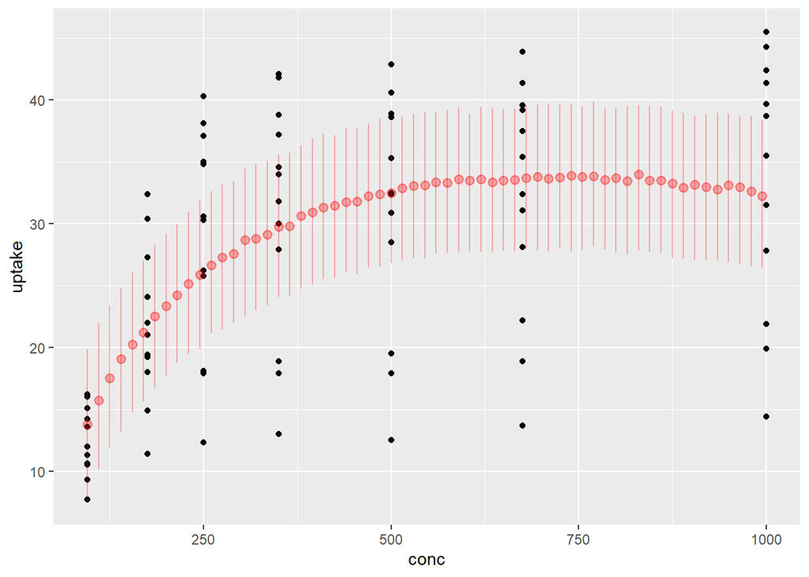

```r
# Create graphical summary of results
df_fit3$pred_50 <- apply(temp_preds2,2,median)
df_fit3$pred_25 <- apply(temp_preds2,2,quantile,probs=0.25)
df_fit3$pred_75 <- apply(temp_preds2,2,quantile,probs=0.75)
# Create a plot of the center and 75% density interval
ggplot(CO2,aes(conc,uptake)) +
  geom_point() +
  geom_pointrange(data=df_fit3, color='red', alpha=0.3,
                  aes(y=pred_50,ymin=pred_25,ymax=pred_75,x=conc))
```

```r
# Compare models
loo3 <- loo(fit3)
loo_compare(loo0,loo1,loo2, loo3)
```

```
##      elpd_diff se_diff
## fit3   0.0       0.0
## fit2  -3.4       1.2
## fit1  -8.8       4.0
## fit0 -18.9       5.9
```

# Multiple linear regression: adding predictors

- More than one predictor
- Otherwise very similar
- What situations do we use more than one predictor?
  - How do we decide what other variables to add in?
  - Should we start with pairwise correlations?
  - Perhaps topical expertise (based on your past knowledge)

# Multivariate regression

- All we need to do is add in the variable to the equation like so:

```r
# Fit model with concentration, specifying priors
fit4 <- stan_glm(uptake ~ conc + I(conc**0.3) + Treatment,
                data = CO2,
                chains=CHAINS,
                seed=SEED)
# Check priors
prior_summary(fit4)
```

```
## Priors for model 'fit4'
## ------
## Intercept (after predictors centered)
##   Specified prior:
##     ~ normal(location = 27, scale = 2.5)
##   Adjusted prior:
##     ~ normal(location = 27, scale = 27)
##
## Coefficients
##   Specified prior:
##     ~ normal(location = [0,0,0], scale = [2.5,2.5,2.5])
##   Adjusted prior:
##     ~ normal(location = [0,0,0], scale = [ 0.091,20.873,53.749])
##
## Auxiliary (sigma)
##   Specified prior:
##     ~ exponential(rate = 1)
##   Adjusted prior:
##     ~ exponential(rate = 0.092)
## ------
## See help('prior_summary.stanreg') for more details
```

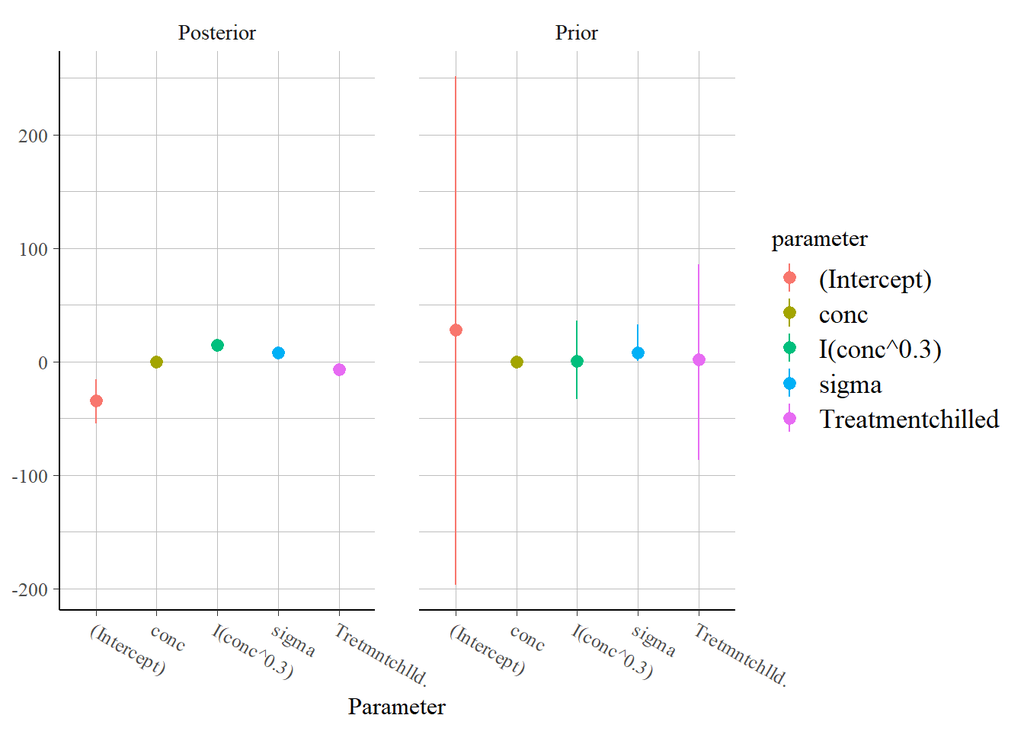

```r
posterior_vs_prior(fit4)
```

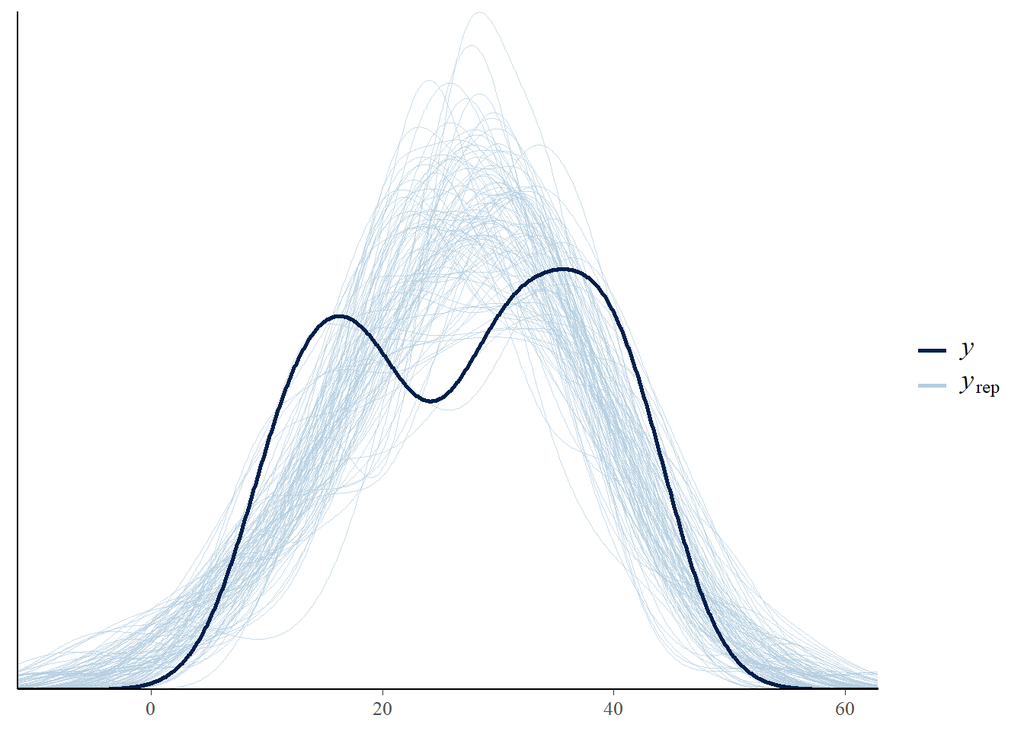

```r
# Overlay multiple densities (first 100) - doing all of them takes awhile
ppc_dens_overlay(y = CO2$uptake,
         yrep = posterior_predict(fit4)[1:100,])
```

```r
# Examine model results
summary(fit4,digits=5)
```

```
##
## Model Info:
##  function:     stan_glm
##  family:       gaussian [identity]
##  formula:      uptake ~ conc + I(conc^0.3) + Treatment
##  algorithm:    sampling
##  sample:       4000 (posterior sample size)
##  priors:       see help('prior_summary')
##  observations: 84
##  predictors:   4
##
## Estimates:
##                    mean      sd        10%       50%       90%
## (Intercept)      -34.81436  11.79925 -50.02756 -34.73945 -20.14644
## conc              -0.04347   0.01271  -0.05984  -0.04340  -0.02770
## I(conc^0.3)       14.36054   2.89633  10.70065  14.36530  18.04767
## Treatmentchilled  -6.84374   1.73421  -8.99229  -6.88450  -4.59393
## sigma              7.89889   0.63370   7.11481   7.87276   8.70848
##
## Fit Diagnostics:
##            mean     sd       10%      50%      90%
## mean_PPD 27.20772  1.22842 25.68956 27.17209 28.79394
##
## The mean_ppd is the sample average posterior predictive distribution of the outcome variable (for details see help('summary.stanreg')).
##
## MCMC diagnostics
##                  mcse    Rhat    n_eff
## (Intercept)      0.27018 1.00118 1907
## conc             0.00029 1.00110 1959
## I(conc^0.3)      0.06642 1.00118 1901
## Treatmentchilled 0.03180 1.00223 2975
## sigma            0.01243 0.99962 2599
## mean_PPD         0.02004 0.99956 3757
## log-posterior    0.05031 1.00105 1157
##
## For each parameter, mcse is Monte Carlo standard error, n_eff is a crude measure of effective sample size, and Rhat is the potential scale reduction factor on split chains (at convergence Rhat=1).
```

- we still have a bimodal Y, but not in our model!

# Confounding

- What is Confounding?
- Ice cream consumption and shark attacks
  - the distortion in an estimated association due to the effect of another variable
  - Confounding is present if there is any meaningful difference between the crude and adjusted estimates.
- How do I address confounding in the model?

> Question: Do you think there is any confounding in this current model, perhaps due to plant type? Fit a model with type added in, and examine the results to tell me if the relationship between treatment and uptake was confounded by type.

# Add in Type

- Let’s add in the Type variable to see

```r
# Fit model with concentration, specifying priors
fit5 <- stan_glm(uptake ~ conc + I(conc**0.3) + Treatment + Type,
                data = CO2,
                chains=CHAINS,
                seed=SEED)
# Check priors
prior_summary(fit5)
```

```
## Priors for model 'fit5'
## ------
## Intercept (after predictors centered)
##   Specified prior:
##     ~ normal(location = 27, scale = 2.5)
##   Adjusted prior:
##     ~ normal(location = 27, scale = 27)
##
## Coefficients
##   Specified prior:
##     ~ normal(location = [0,0,0,...], scale = [2.5,2.5,2.5,...])
##   Adjusted prior:
##     ~ normal(location = [0,0,0,...], scale = [ 0.091,20.873,53.749,...])
##
## Auxiliary (sigma)
##   Specified prior:
##     ~ exponential(rate = 1)
##   Adjusted prior:
##     ~ exponential(rate = 0.092)
## ------
## See help('prior_summary.stanreg') for more details
```

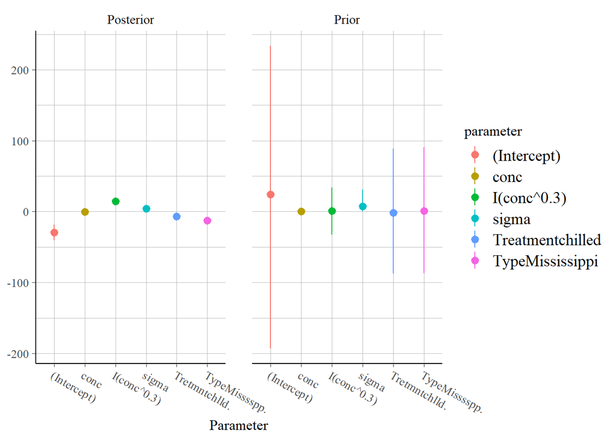

```r
posterior_vs_prior(fit5)
```

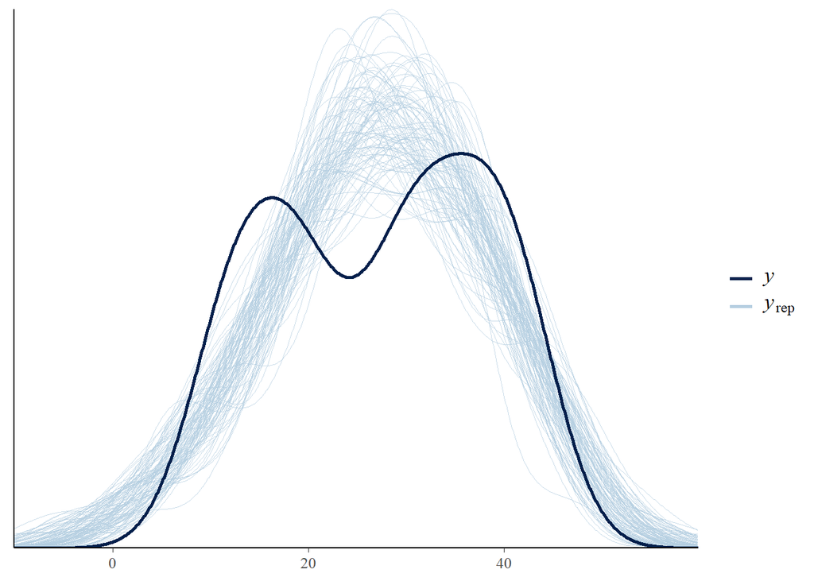

```r
# Overlay multiple densities (first 100) - doing all of them takes awhile
ppc_dens_overlay(y = CO2$uptake,
         yrep = posterior_predict(fit5)[1:100,])
```

```r
# Examine model results
summary(fit5,digits=5)
```

```
##
## Model Info:
##  function:     stan_glm
##  family:       gaussian [identity]
##  formula:      uptake ~ conc + I(conc^0.3) + Treatment + Type
##  algorithm:    sampling
##  sample:       4000 (posterior sample size)
##  priors:       see help('prior_summary')
##  observations: 84
##  predictors:   5
##
## Estimates:
##                    mean      sd        10%       50%       90%
## (Intercept)      -29.42145   6.87920 -37.99996 -29.46109 -20.57861
## conc              -0.04442   0.00743  -0.05374  -0.04429  -0.03482
## I(conc^0.3)       14.59099   1.69751  12.42694  14.58391  16.73362
## Treatmentchilled  -6.84747   0.97045  -8.10142  -6.84525  -5.59869
## TypeMississippi  -12.64301   0.98195 -13.89764 -12.64056 -11.39445
## sigma              4.43535   0.34566   4.00904   4.41087   4.88854
##
## Fit Diagnostics:
##            mean     sd       10%      50%      90%
## mean_PPD 27.22443  0.70001 26.34778 27.23376 28.10514
##
## The mean_ppd is the sample average posterior predictive distribution of the outcome variable (for details see help('summary.stanreg')).
##
## MCMC diagnostics
##                  mcse    Rhat    n_eff
## (Intercept)      0.14609 1.00072 2217
## conc             0.00016 1.00080 2247
## I(conc^0.3)      0.03613 1.00079 2208
## Treatmentchilled 0.01505 0.99924 4160
## TypeMississippi  0.01598 0.99966 3775
## sigma            0.00591 1.00186 3420
## mean_PPD         0.01107 1.00130 4002
## log-posterior    0.04490 1.00404 1578
##
## For each parameter, mcse is Monte Carlo standard error, n_eff is a crude measure of effective sample size, and Rhat is the potential scale reduction factor on split chains (at convergence Rhat=1).
```

# MLR with interactions

- What about effect modification, also called interaction?
- This is where the association between a predictor and the outcome depends on values of another predictor
  - if the effect of one variable differs or varies across the levels of the other variable
  - x modifies z and z modifies x
- A simple example would be the effect of birth control and fertility. The relationship between taking birth control pills and fertility would be different for men and women.
- We put interaction terms into the model explicitly as shown below

```r
# Fit model with concentration, specifying priors
fit6 <- stan_glm(uptake ~ conc + I(conc**0.3) + Type*Treatment,
                data = CO2,
                chains=CHAINS,
                seed=SEED)
# Check priors
prior_summary(fit6)
```

```
## Priors for model 'fit6'
## ------
## Intercept (after predictors centered)
##   Specified prior:
##     ~ normal(location = 27, scale = 2.5)
##   Adjusted prior:
##     ~ normal(location = 27, scale = 27)
##
## Coefficients
##   Specified prior:
##     ~ normal(location = [0,0,0,...], scale = [2.5,2.5,2.5,...])
##   Adjusted prior:
##     ~ normal(location = [0,0,0,...], scale = [ 0.091,20.873,53.749,...])
##
## Auxiliary (sigma)
##   Specified prior:
##     ~ exponential(rate = 1)
##   Adjusted prior:
##     ~ exponential(rate = 0.092)
## ------
## See help('prior_summary.stanreg') for more details
```

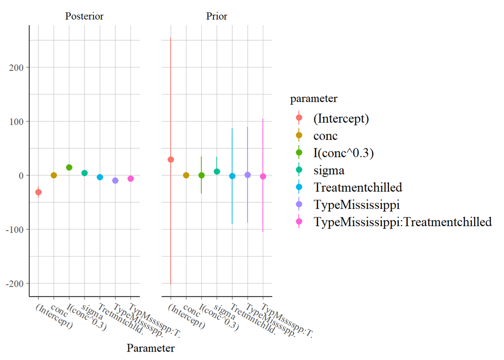

```r
posterior_vs_prior(fit6)
```

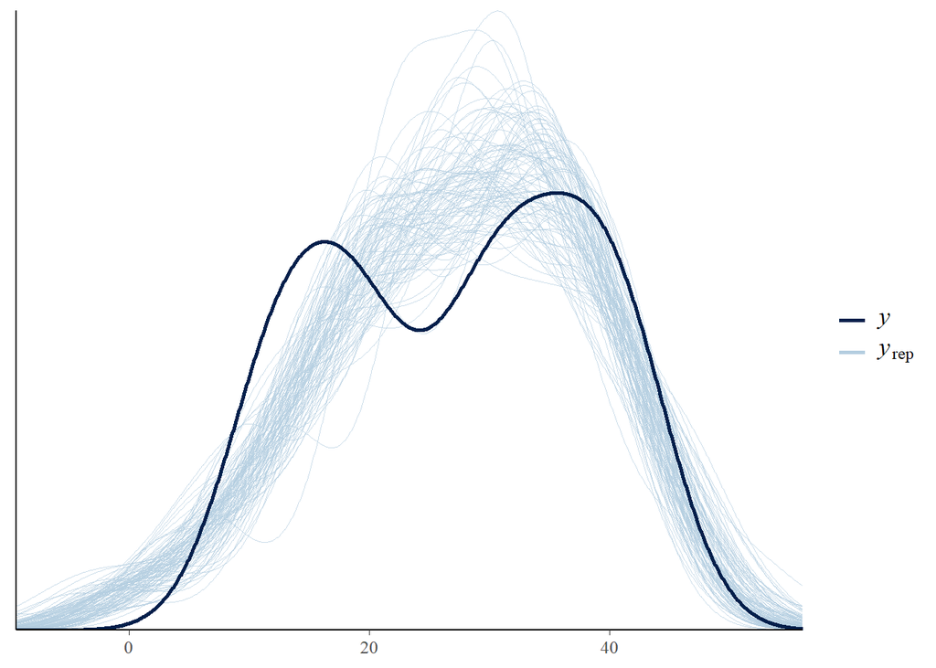

```r
# Overlay multiple densities (first 100) - doing all of them takes awhile
ppc_dens_overlay(y = CO2$uptake,
         yrep = posterior_predict(fit6)[1:100,])
```

```r
# Examine model results
summary(fit6,digits=5)
```

```
##
## Model Info:
##  function:     stan_glm
##  family:       gaussian [identity]
##  formula:      uptake ~ conc + I(conc^0.3) + Type * Treatment
##  algorithm:    sampling
##  sample:       4000 (posterior sample size)
##  priors:       see help('prior_summary')
##  observations: 84
##  predictors:   6
##
## Estimates:
##                                    mean      sd        10%       50%       90%
## (Intercept)                      -31.15916   6.23553 -39.08497 -31.16610 -23.16102
## conc                              -0.04456   0.00668  -0.05309  -0.04441  -0.03598
## I(conc^0.3)                       14.61797   1.52978  12.65439  14.61004  16.56059
## TypeMississippi                   -9.37713   1.30867 -11.09649  -9.36560  -7.71199
## Treatmentchilled                  -3.57914   1.28405  -5.25075  -3.56355  -1.91767
## TypeMississippi:Treatmentchilled  -6.55863   1.85493  -8.91014  -6.51357  -4.22632
## sigma                              4.11351   0.33858   3.69450   4.10104   4.53673
##
## Fit Diagnostics:
##            mean     sd       10%      50%      90%
## mean_PPD 27.21043  0.63319 26.39339 27.21371 28.00439
##
## The mean_ppd is the sample average posterior predictive distribution of the outcome variable (for details see help('summary.stanreg')).
##
## MCMC diagnostics
##                                  mcse    Rhat    n_eff
## (Intercept)                      0.13478 0.99915 2140
## conc                             0.00015 0.99919 2116
## I(conc^0.3)                      0.03338 0.99915 2101
## TypeMississippi                  0.02915 1.00132 2015
## Treatmentchilled                 0.02857 1.00102 2020
## TypeMississippi:Treatmentchilled 0.04429 1.00093 1754
## sigma                            0.00602 0.99992 3166
## mean_PPD                         0.01098 1.00108 3328
## log-posterior                    0.04938 1.00145 1559
##
## For each parameter, mcse is Monte Carlo standard error, n_eff is a crude measure of effective sample size, and Rhat is the potential scale reduction factor on split chains (at convergence Rhat=1).
```

- That is a lot of output to digest! Were those models an improvement? How well are we approximating the posterior?
- The posterior density plot makes me think we still do not have the model correct.

# MLR with interactions…part 2

- Let’s try a few more interactions, mimicking the plot we made at the very start of the lecture.

```r
# Fit model with concentration, specifying priors
fit7 <- stan_glm(uptake ~ conc*Type*Treatment + I(conc**0.3)*Type*Treatment,
                data = CO2,
                chains=CHAINS,
                seed=SEED)
# Check priors
prior_summary(fit7)
```

```
## Priors for model 'fit7'
## ------
## Intercept (after predictors centered)
##   Specified prior:
##     ~ normal(location = 27, scale = 2.5)
##   Adjusted prior:
##     ~ normal(location = 27, scale = 27)
##
## Coefficients
##   Specified prior:
##     ~ normal(location = [0,0,0,...], scale = [2.5,2.5,2.5,...])
##   Adjusted prior:
##     ~ normal(location = [0,0,0,...], scale = [ 0.091,53.749,53.749,...])
##
## Auxiliary (sigma)
##   Specified prior:
##     ~ exponential(rate = 1)
##   Adjusted prior:
##     ~ exponential(rate = 0.092)
## ------
## See help('prior_summary.stanreg') for more details
```

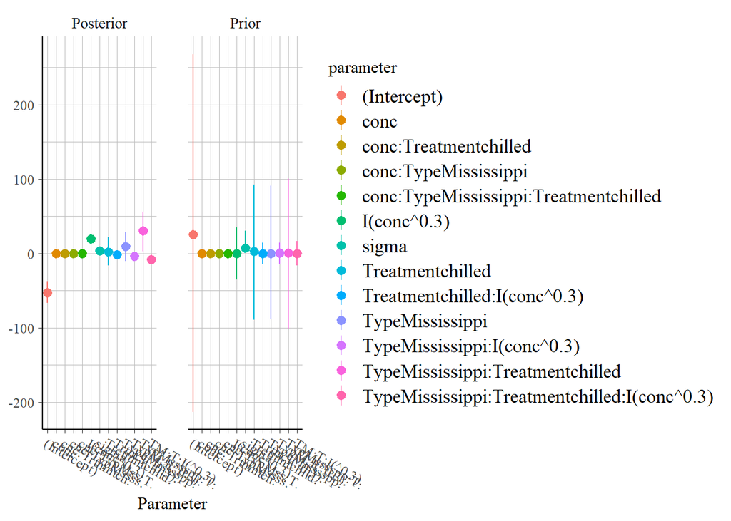

```r
posterior_vs_prior(fit7)
```

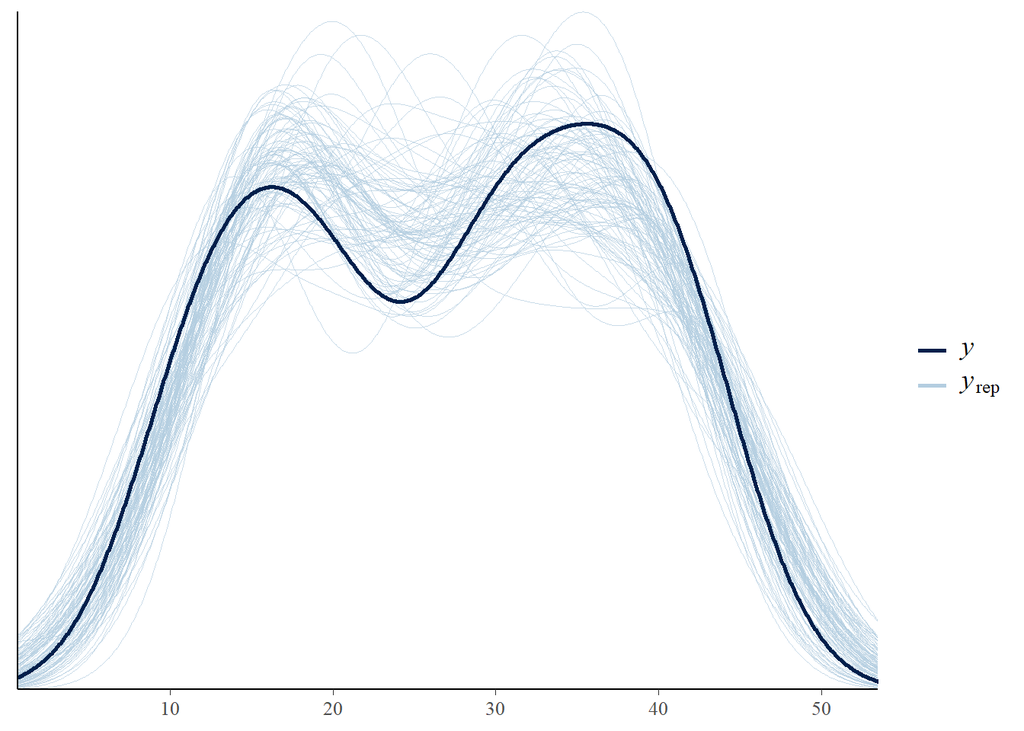

```r
# Overlay multiple densities (first 100) - doing all of them takes awhile
ppc_dens_overlay(y = CO2$uptake,
         yrep = posterior_predict(fit7)[1:100,])
```

```r
# Examine model results
summary(fit7,digits=5)
```

```
##
## Model Info:
##  function:     stan_glm
##  family:       gaussian [identity]
##  formula:      uptake ~ conc * Type * Treatment + I(conc^0.3) * Type * Treatment
##  algorithm:    sampling
##  sample:       4000 (posterior sample size)
##  priors:       see help('prior_summary')
##  observations: 84
##  predictors:   12
##
## Estimates:
##                                                mean      sd        10%       50%       90%
## (Intercept)                                  -52.40939   8.68228 -63.57385 -52.36949 -41.31003
## conc                                          -0.06029   0.00940  -0.07210  -0.06036  -0.04815
## TypeMississippi                                8.86404  11.83274  -6.39548   8.98906  23.91322
## Treatmentchilled                               2.25461  11.46956 -12.07171   2.22816  17.07375
## I(conc^0.3)                                   19.40010   2.13299  16.64174  19.38290  22.11075
## conc:TypeMississippi                           0.01178   0.01294  -0.00482   0.01168   0.02840
## conc:Treatmentchilled                          0.00802   0.01250  -0.00775   0.00773   0.02438
## TypeMississippi:Treatmentchilled              30.12401  15.77554  10.31281  30.40183  50.17147
## TypeMississippi:I(conc^0.3)                   -3.98018   2.92036  -7.72745  -3.98835  -0.23461
## Treatmentchilled:I(conc^0.3)                  -1.58681   2.81811  -5.19266  -1.56451   1.91772
## conc:TypeMississippi:Treatmentchilled          0.02289   0.01723   0.00039   0.02345   0.04503
## TypeMississippi:Treatmentchilled:I(conc^0.3)  -7.93889   3.87943 -12.82967  -8.00524  -2.99882
## sigma                                          3.29271   0.27048   2.96851   3.27429   3.63989
##
## Fit Diagnostics:
##            mean     sd       10%      50%      90%
## mean_PPD 27.20774  0.50796 26.54353 27.21594 27.83574
##
## The mean_ppd is the sample average posterior predictive distribution of the outcome variable (for details see help('summary.stanreg')).
##
## MCMC diagnostics
##                                              mcse    Rhat    n_eff
## (Intercept)                                  0.25191 1.00121 1188
## conc                                         0.00028 1.00078 1154
## TypeMississippi                              0.36074 1.00194 1076
## Treatmentchilled                             0.35249 1.00302 1059
## I(conc^0.3)                                  0.06332 1.00111 1135
## conc:TypeMississippi                         0.00038 1.00126 1137
## conc:Treatmentchilled                        0.00040 1.00293  993
## TypeMississippi:Treatmentchilled             0.48883 1.00369 1041
## TypeMississippi:I(conc^0.3)                  0.08965 1.00173 1061
## Treatmentchilled:I(conc^0.3)                 0.08917 1.00322  999
## conc:TypeMississippi:Treatmentchilled        0.00053 1.00290 1053
## TypeMississippi:Treatmentchilled:I(conc^0.3) 0.12195 1.00352 1012
## sigma                                        0.00479 0.99947 3192
## mean_PPD                                     0.00895 0.99988 3221
## log-posterior                                0.07233 0.99950 1376
##
## For each parameter, mcse is Monte Carlo standard error, n_eff is a crude measure of effective sample size, and Rhat is the potential scale reduction factor on split chains (at convergence Rhat=1).
```

- That is a lot of output to digest! Were those models an improvement?
- The posterior plot looks much better. This model is a good approximation to the data apparently.

> Question: Use the loo function to check if this model gives us a better fit.

# Comparing models answer

> Answer to prior question:

```r
loo4 <- loo(fit4)
loo5 <- loo(fit5)
loo6 <- loo(fit6)
loo7 <- loo(fit7)
loo_compare(loo0,loo1,loo2, loo3, loo4, loo5, loo6, loo7)
```

```
##      elpd_diff se_diff
## fit7   0.0       0.0
## fit6 -16.3       5.8
## fit5 -21.9       5.9
## fit4 -69.5       6.5
## fit3 -76.3       7.3
## fit2 -79.6       6.9
## fit1 -85.0       6.8
## fit0 -95.2       6.9
```

# Creating a graphical representation of our results

- As an exercise, I want you to generate a dataframe with a range of predictor values, then visualize the results from model 6. You will need to examine the model components, then create a dataframe that has variation across the relevant variables. I will help you get started with the dataframe creation:

```r
# Use expand.grid to generate the cartesian product of these values
df_mod7 <-
  expand.grid(conc=seq(100,1000,25),
            Type=c('Quebec','Mississippi'),
            Treatment=c('nonchilled','chilled'))
# Make predictions on this dataframe

# Summarize predictions

# Visualize results
```

# Creating a graphical representation of our results

- As an exercise, I want you to generate a dataframe with a range of predictor values, then visualize the results from model 6. You will need to examine the model components, then create a dataframe that has variation across the relevant variables. I will help you get started with the dataframe creation:

```r
# Use expand.grid to generate the cartesian product of these values
df_mod6 <-
  expand.grid(conc=seq(100,1000,25),
            Type=c('Quebec','Mississippi'),
            Treatment=c('nonchilled','chilled'))
# make posterior predictions according to the model
temp_preds3 <- posterior_predict(fit6,newdata = df_mod6)
str(temp_preds3)
```

```
##  'ppd' num [1:4000, 1:148] 17.6 29 21.5 27 24.5 ...
##  - attr(*, "dimnames")=List of 2
##   ..$ : NULL
##   ..$ : chr [1:148] "1" "2" "3" "4" ...
```

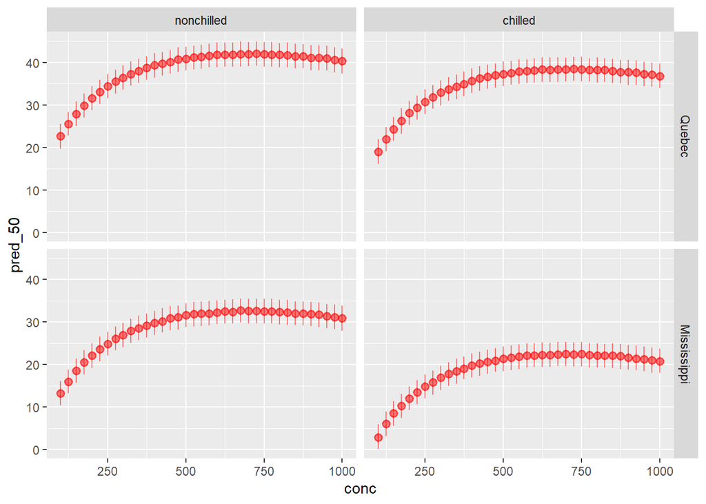

```r
# Create graphical summary of results
df_mod6$pred_50 <- apply(temp_preds3,2,median)
df_mod6$pred_25 <- apply(temp_preds3,2,quantile,probs=0.25)
df_mod6$pred_75 <- apply(temp_preds3,2,quantile,probs=0.75)
# Create a plot of the center and 75% density interval
ggplot(df_mod6, aes(y=pred_50,ymin=pred_25,ymax=pred_75,x=conc)) +
  geom_pointrange(color='red', alpha=0.5) +
  facet_grid(Type~Treatment)
```

- The `posterior_predict()` function is prediction (and uncertainty) about individual values
- Conversely, the `posterior_linpred()` function is prediction of the expected value (the mean of the linear predictors)

> Question: Alter your code above to use the `posterior_linpred()` instead of `posterior_predict()` to see the difference in the uncertainty estimates.

# Answer Using linpred

```r
# Use expand.grid to generate the cartesian product of these values
df_mod6 <-
  expand.grid(conc=seq(100,1000,25),
            Type=c('Quebec','Mississippi'),
            Treatment=c('nonchilled','chilled'))
# make posterior predictions according to the model
temp_preds3 <- posterior_linpred(fit6,newdata = df_mod6)
str(temp_preds3)
```

```
##  num [1:4000, 1:148] 25.3 24.9 25.4 24.1 22.8 ...
##  - attr(*, "dimnames")=List of 2
##   ..$ iterations: NULL
##   ..$           : chr [1:148] "1" "2" "3" "4" ...
```

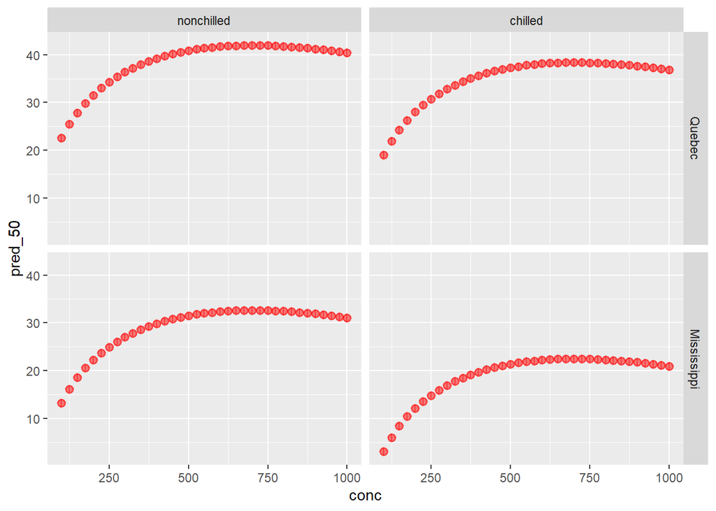

```r
# Create graphical summary of results
df_mod6$pred_50 <- apply(temp_preds3,2,median)
df_mod6$pred_25 <- apply(temp_preds3,2,quantile,probs=0.25)
df_mod6$pred_75 <- apply(temp_preds3,2,quantile,probs=0.75)
# Create a plot of the center and 75% density interval
ggplot(df_mod6, aes(y=pred_50,ymin=pred_25,ymax=pred_75,x=conc)) +
  geom_pointrange(color='red', alpha=0.5) +
  facet_grid(Type~Treatment)
```

# Regression diagnostics

- Rstanarm estimates the posterior using a Markov Chain Monte Carlo (MCMC) algorithm called Hamiltonian Monte Carlo. The details of this algorithm are beyond the scope of this course, however, I will give some practical advice on how to interpret the results found in the GUI shiny app that comes with STAN.

```r
# launch_shinystan(fit6)
```

# Glossary

`fit <- stan_glm(y~x,data)` general linear regression with MCMC  
`y ~ x1 + x2 + I(x3*3)` formula object  
`summary(fit)` summary of fit object  
`expand.grid()` expand all combinations  
`plot(fit)` regression diagnostic plots  
`posterior_linpred()` get predictions for the expected value `posterior_predict()` get predictions for the individuals `loo(fit)` calculate leave one out